# Flexible Damage Functions

Author

James Rising, Sebastian Cadavid Sanchez, Climate Impact Lab

Published

April 30, 2026

## 0.1 Mortality: Allcause Country

Flexible damage function parameters at the Country level.

**Change in all-cause all-age mortality rate (deaths per 100,000) under full adaptation with adaptation costs**

**Outcome units:** `physical` — deaths per 100,000 population (population-weighted mean across IRs within each country)

$$D_{it} = (\alpha_i T_t + \beta_i T_t^2) \cdot Y_{it}^{\gamma}$$

where $\gamma$ is the income elasticity (fitted globally), $\alpha_i$ is the linear coefficient, and $\beta_i$ is the quadratic coefficient.

# 1 Global Estimation

## 1.1 Income Elasticity Estimation

The income elasticity $\gamma$ is estimated using a fixed-effects regression:

$$y_{it} = \gamma \cdot \log(Y_{it}) + \mu_{g(i,T)} + \nu_t + \varepsilon_{it}$$

where $\mu_{g(i,T)}$ are region-by-temperature-bin fixed effects and $\nu_t$ are year fixed effects.

Table 1: Income Elasticity (Gamma) Estimation Results

| Statistic | Value |
| --- | --- |
| Income elasticity ($\gamma$) | -0.0002 |
| Standard error | 1.83e-05 |
| 95% CI | [-0.0002, -0.0001] |
| R-squared | 0.8699 |
| Observations | 335,160 |
| Regions | 245 |
| Gamma quantiles | 19 |

# 2 Parameter Distributions

## 2.1 8-Panel Summary

Row 1: gamma, alpha, beta, rsqr1. Row 2: rho, zeta, eta, rsqr2.

```
Using median gamma: -0.000159, 4,655 rows (of 4,655 total)
```

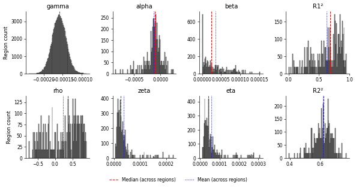

Figure 1: Distribution of Regional Parameters

## 2.2 Projection Equation and Parameter Definitions

The estimated parameters are used to project damages via Monte Carlo sampling:

$$D_{it}^k = (\hat{\alpha}_{ik} T_t + \hat{\beta}_{ik} T_t^2) Y_{it}^{\hat{\gamma}_k} + \hat{\theta}_{ik} T_t Y_{it}^{\hat{\gamma}_k} + \hat{\phi}_{it}^k$$

where $k$ indexes the Monte Carlo draw. The parameters in each row of the output CSV control distinct components of this equation:

- **gamma**: income elasticity $\hat{\gamma}_k$, one of 19 quantile values drawn from $N(\hat{\gamma}, SE(\hat{\gamma}))$
- **alpha, beta**: linear and quadratic temperature coefficients; $\hat{\alpha}_{ik}$ and $\hat{\beta}_{ik}$ are drawn from the joint normal defined by the VCV below
- **sigma11, sigma12, sigma22**: variance-covariance matrix of $(\alpha, \beta)$, used for joint uncertainty sampling
- **rho**: correlation between regional and global polynomial residuals $\rho_i$, used to maintain spatial covariance across regions in Monte Carlo draws
- **zeta**: temperature-dependent error scale $\zeta_{ik}$; the run-specific error term $\hat{\theta}_{ik}$ is drawn from $N(0, \zeta_{ik})$
- **eta**: residual noise standard deviation $\eta_{ik}$; the annual noise $\hat{\phi}_{it}^k$ is drawn from $N(0, \eta_{ik})$
- **rsqr1, rsqr2**: polynomial fit quality and error model fit, respectively

## 2.3 Summary Statistics

Table 2: Regional Parameter Summary

| Parameter | Mean | Median | Std | Min | Max | N |
| --- | --- | --- | --- | --- | --- | --- |
| alpha | -0.0001262 | -0.000106 | 0.0001625 | -0.0008538 | 0.0002472 | 245 |
| beta | 3.456e-05 | 2.417e-05 | 3.26e-05 | 0 | 0.0001523 | 245 |
| rho | 0.2234 | 0.3709 | 0.4648 | -0.7527 | 0.9014 | 245 |
| zeta | 3.682e-05 | 2.619e-05 | 3.547e-05 | 6.264e-06 | 0.0002268 | 245 |
| eta | 5.76e-05 | 4.145e-05 | 5.55e-05 | 9.889e-06 | 0.0003083 | 245 |
| rsqr1 | 0.627 | 0.6852 | 0.2359 | 0.004795 | 0.9528 | 245 |
| rsqr2 | 0.6173 | 0.6207 | 0.06123 | 0.3939 | 0.7734 | 245 |

# 3 Spaghetti Curves

Regional damage function curves showing D(T) = αT + βT² for sampled regions.

[interactive chart not shown]

Figure 2: Regional Damage Functions

# 4 Zero Crossings

The zero crossing (extremum) of the parabola occurs at $T^* = -\alpha / (2\beta)$.

Table 3: Zero Crossing Statistics

| Category | Count | Percentage |
| --- | --- | --- |
| β = 0 (no crossing) | 33 | 13.5% |
| T > 20°C (beyond graph) | 5 | 2.0% |
| T < 0°C (negative crossing) | 35 | 14.3% |
| Valid crossings (0-20°C) | 172 | 70.2% |

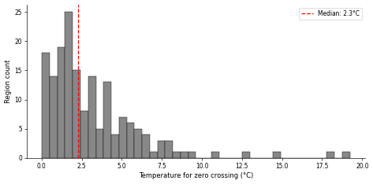

Figure 3: Distribution of Zero Crossing Temperatures

# 5 Slope Analysis

Maximum slope between 0 and 10°C: $\frac{dM}{dT} = \alpha + 2\beta T$

The maximum occurs at either T=0 or T=10 (endpoints of interval).

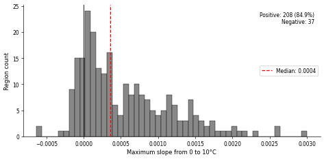

Figure 4: Distribution of Maximum Slopes (0-10°C)

*Convexity analysis omitted (beta constraint active).*

# 6 R-squared Analysis

## 6.1 Polynomial Fit Quality (rsqr1)

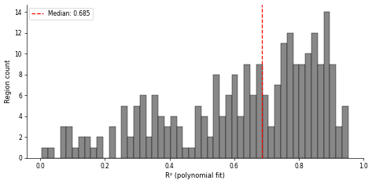

Figure 5: Regional Fit Quality (R-squared)

## 6.2 Error Model R-squared (rsqr2) Quantiles

Table 4: rsqr2 Quantiles

| 0% (Min) | 25% | 50% (Median) | 75% | 100% (Max) |
| --- | --- | --- | --- | --- |
| 0.3939 | 0.5802 | 0.6207 | 0.6590 | 0.7734 |

# 7 Modelled Variance

Modelled variance statistic: $1 - \frac{\sum_i \eta_i^2}{\sum_i D_i^2}$

Table 5: Modelled Variance Statistics

| Statistic | Value |
| --- | --- |
| Modelled variance | 0.9745 |
| Sum(η²) | 0.0000 |
| Sum(D²) at T=3.0°C | 0.0001 |
| N regions | 245 |

# 8 Best- and Worst-Fitting Regions

The 3 worst- and 3 best-fitting regions by R-squared, with raw simulation data overlaid on the fitted polynomial curve. **Red rows = worst fits**, **green rows = best fits**.

Table 6: Best- and worst-fitting regions

Top 3 best fit (R²) Top 3 worst fit (R²)

| Region | α | β | η | R² |
| --- | --- | --- | --- | --- |
| USA | -3.48e-5 | 3.01e-5 | 1.34e-5 | 0.953 |
| GRC | 1.19e-4 | 4.90e-6 | 1.73e-5 | 0.951 |
| JPN | 6.64e-5 | 1.48e-5 | 1.84e-5 | 0.949 |
| SHN | -1.00e-7 | 1.52e-6 | 5.35e-5 | 0.00479 |
| CHL | 3.28e-6 | 4.08e-6 | 5.77e-5 | 0.0421 |
| COM | -6.84e-5 | 1.54e-5 | 3.69e-5 | 0.069 |

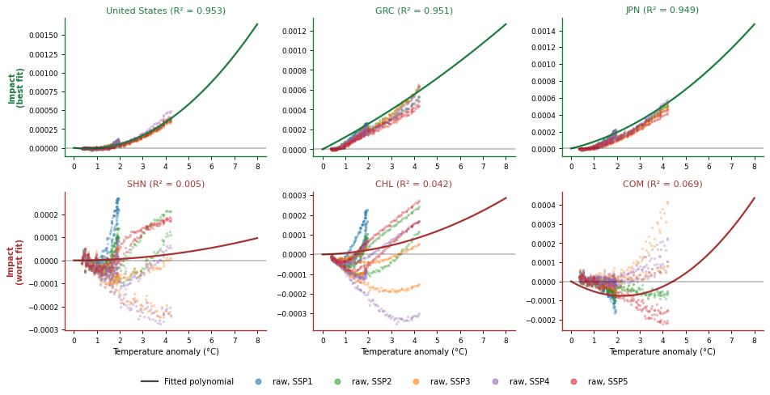

# 9 Regional Parameter Maps

## 9.1 Alpha (Linear Coefficient)

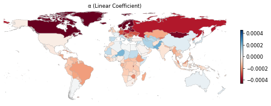

Figure 7: α (linear coefficient)

## 9.2 Beta (Quadratic Coefficient)

Beta ($\beta$) represents the curvature of the damage function.

The convexity ($\beta \geq 0$) constraint is enforced for this sector, meaning damages accelerate with warming (U-shaped response).

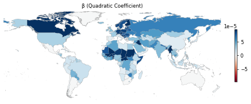

Figure 8: β (quadratic coefficient)

## 9.3 R-squared (Fit Quality)

$R^2$ measures the polynomial fit quality. Higher values indicate that the quadratic form captures more of the variance in the data.

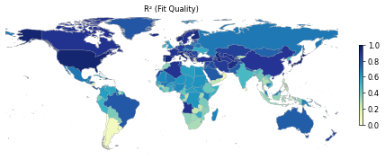

Figure 9: R² (stage 1 fit quality)

# 10 F2: Flex vs Raw Comparison

Comparison of flexible damage function predictions against raw simulation means.

For each scenario (RCP × SSP × Model), we compute at the final year:

- **Flex predicted**: $(\alpha \cdot T + \beta \cdot T^2) \cdot Y^\gamma$
- **Raw actual**: The outcome variable (y) from the source data

**Year 2099**: 4,048 rows

**rcp45**

**SSP1**

**high**

**Correlation:** 0.8112 | **RMSE:** 0.000205 | **Sign agreement:** 78.0%

[interactive chart not shown]

Top 5 best predicted Top 5 worst predicted

Year 2099 · T<sub>mean</sub> across these regions: 1.96°C

| Region | Raw | Flex | Residual |
| --- | --- | --- | --- |
| MOZ | -3.79e-5 | -3.95e-5 | -1.57e-6 |
| SAU | 1.26e-4 | 1.31e-4 | 4.68e-6 |
| UKR | -3.26e-4 | -3.19e-4 | 7.11e-6 |
| KAZ | -1.36e-4 | -1.28e-4 | 8.06e-6 |
| HKG | -1.28e-4 | -1.18e-4 | 1.03e-5 |
| SJM | -0.00211 | -0.00124 | 8.77e-4 |
| NER | 2.00e-6 | 7.57e-4 | 7.55e-4 |
| BFA | 7.90e-6 | 6.69e-4 | 6.61e-4 |
| DJI | 7.51e-5 | 7.25e-4 | 6.50e-4 |
| BDI | 1.24e-4 | -4.54e-4 | -5.79e-4 |

**low**

**Correlation:** 0.9259 | **RMSE:** 0.000134 | **Sign agreement:** 89.8%

[interactive chart not shown]

Top 5 best predicted Top 5 worst predicted

Year 2099 · T<sub>mean</sub> across these regions: 1.96°C

| Region | Raw | Flex | Residual |
| --- | --- | --- | --- |
| KIR | -1.09e-4 | -1.10e-4 | -9.84e-7 |
| THA | -1.04e-4 | -1.06e-4 | -2.23e-6 |
| LBY | 6.39e-5 | 6.11e-5 | -2.76e-6 |
| ABW | -2.07e-5 | -2.43e-5 | -3.65e-6 |
| ISR | -1.43e-5 | -1.01e-5 | 4.13e-6 |
| SJM | -0.00181 | -0.00124 | 5.72e-4 |
| SOM | 9.69e-5 | 4.83e-4 | 3.86e-4 |
| ALB | 5.05e-4 | 1.57e-4 | -3.49e-4 |
| ALA | -0.00106 | -7.23e-4 | 3.36e-4 |
| HRV | 3.11e-4 | -1.02e-5 | -3.21e-4 |

**SSP2**

**high**

**Correlation:** 0.9013 | **RMSE:** 0.000142 | **Sign agreement:** 88.6%

[interactive chart not shown]

Top 5 best predicted Top 5 worst predicted

Year 2099 · T<sub>mean</sub> across these regions: 1.96°C

| Region | Raw | Flex | Residual |
| --- | --- | --- | --- |
| SYC | -1.95e-4 | -1.94e-4 | 8.09e-7 |
| MHL | -2.26e-4 | -2.27e-4 | -9.47e-7 |
| TKL | -4.40e-5 | -4.31e-5 | 9.71e-7 |
| VGB | -1.97e-4 | -1.96e-4 | 1.00e-6 |
| BES | -2.37e-4 | -2.36e-4 | 1.02e-6 |
| DJI | 6.36e-5 | 7.25e-4 | 6.61e-4 |
| NER | 1.30e-4 | 7.57e-4 | 6.27e-4 |
| BFA | 1.19e-4 | 6.69e-4 | 5.50e-4 |
| SDN | 1.21e-4 | 6.35e-4 | 5.14e-4 |
| TCD | 1.22e-4 | 5.50e-4 | 4.27e-4 |

**low**

**Correlation:** 0.9628 | **RMSE:** 0.000106 | **Sign agreement:** 89.8%

[interactive chart not shown]

Top 5 best predicted Top 5 worst predicted

Year 2099 · T<sub>mean</sub> across these regions: 1.96°C

| Region | Raw | Flex | Residual |
| --- | --- | --- | --- |
| DMA | -2.82e-4 | -2.82e-4 | -3.72e-7 |
| SMX | -1.67e-4 | -1.67e-4 | 5.22e-7 |
| MAF | -1.67e-4 | -1.67e-4 | 5.24e-7 |
| TCA | -1.75e-4 | -1.76e-4 | -9.47e-7 |
| GMB | 1.19e-4 | 1.17e-4 | -1.02e-6 |
| BIH | 6.65e-5 | -2.83e-4 | -3.50e-4 |
| SDN | 3.19e-4 | 6.35e-4 | 3.17e-4 |
| SOM | 1.97e-4 | 4.83e-4 | 2.86e-4 |
| FIN | -9.48e-4 | -0.00123 | -2.85e-4 |
| MKD | 1.54e-4 | -1.21e-4 | -2.75e-4 |

**SSP3**

**high**

**Correlation:** 0.9268 | **RMSE:** 0.000154 | **Sign agreement:** 91.4%

[interactive chart not shown]

Top 5 best predicted Top 5 worst predicted

Year 2099 · T<sub>mean</sub> across these regions: 1.96°C

| Region | Raw | Flex | Residual |
| --- | --- | --- | --- |
| PRT | 1.42e-4 | 1.43e-4 | 1.73e-6 |
| GIN | -1.94e-5 | -1.77e-5 | 1.75e-6 |
| CHN | 1.45e-4 | 1.47e-4 | 2.05e-6 |
| ISR | -8.02e-6 | -1.01e-5 | -2.10e-6 |
| AUS | 6.04e-5 | 6.36e-5 | 3.18e-6 |
| SJM | -6.01e-4 | -0.00124 | -6.34e-4 |
| GRL | -5.62e-4 | -0.00111 | -5.45e-4 |
| DJI | 2.11e-4 | 7.25e-4 | 5.14e-4 |
| MNG | -2.52e-4 | -7.19e-4 | -4.67e-4 |
| LVA | -2.76e-4 | -7.10e-4 | -4.34e-4 |

**low**

**Correlation:** 0.8947 | **RMSE:** 0.000170 | **Sign agreement:** 88.6%

[interactive chart not shown]

Top 5 best predicted Top 5 worst predicted

Year 2099 · T<sub>mean</sub> across these regions: 1.96°C

| Region | Raw | Flex | Residual |
| --- | --- | --- | --- |
| UGA | -1.35e-4 | -1.35e-4 | 5.62e-7 |
| BWA | -6.12e-5 | -6.06e-5 | 5.92e-7 |
| PCN | -7.67e-5 | -7.59e-5 | 7.13e-7 |
| ECU | -1.08e-4 | -1.09e-4 | -1.14e-6 |
| WSM | -9.58e-5 | -9.77e-5 | -1.88e-6 |
| SJM | -5.35e-4 | -0.00124 | -7.00e-4 |
| BFA | 0.00135 | 6.70e-4 | -6.85e-4 |
| MLI | 0.00118 | 4.96e-4 | -6.83e-4 |
| TCD | 0.0012 | 5.50e-4 | -6.50e-4 |
| NER | 0.00134 | 7.58e-4 | -5.87e-4 |

**SSP4**

**high**

**Correlation:** 0.9421 | **RMSE:** 0.000112 | **Sign agreement:** 91.8%

[interactive chart not shown]

Top 5 best predicted Top 5 worst predicted

Year 2099 · T<sub>mean</sub> across these regions: 1.96°C

| Region | Raw | Flex | Residual |
| --- | --- | --- | --- |
| BES | -2.35e-4 | -2.36e-4 | -4.35e-7 |
| SWZ | -1.32e-4 | -1.32e-4 | -5.67e-7 |
| SYC | -1.93e-4 | -1.94e-4 | -7.54e-7 |
| GUY | 2.47e-5 | 2.37e-5 | -1.03e-6 |
| USA | 4.84e-5 | 4.71e-5 | -1.34e-6 |
| MMR | 8.58e-4 | 8.49e-5 | -7.73e-4 |
| SOM | 0.00125 | 4.83e-4 | -7.71e-4 |
| DJI | 1.84e-4 | 7.25e-4 | 5.42e-4 |
| SDN | 9.56e-4 | 6.36e-4 | -3.21e-4 |
| MLI | 8.05e-4 | 4.96e-4 | -3.09e-4 |

**low**

**Correlation:** 0.9619 | **RMSE:** 0.000108 | **Sign agreement:** 89.0%

[interactive chart not shown]

Top 5 best predicted Top 5 worst predicted

Year 2099 · T<sub>mean</sub> across these regions: 1.96°C

| Region | Raw | Flex | Residual |
| --- | --- | --- | --- |
| AIA | -1.83e-4 | -1.83e-4 | 5.31e-7 |
| ESH | -1.17e-4 | -1.16e-4 | 9.66e-7 |
| SMX | -1.65e-4 | -1.67e-4 | -1.77e-6 |
| MAF | -1.65e-4 | -1.67e-4 | -1.79e-6 |
| VEN | -2.20e-4 | -2.18e-4 | 1.93e-6 |
| MMR | 9.45e-4 | 8.49e-5 | -8.60e-4 |
| BFA | 0.00107 | 6.70e-4 | -4.01e-4 |
| MLI | 8.17e-4 | 4.96e-4 | -3.22e-4 |
| SJM | -9.24e-4 | -0.00124 | -3.11e-4 |
| GRL | -8.26e-4 | -0.00111 | -2.81e-4 |

**SSP5**

**high**

*No data for this scenario.*

**low**

*No data for this scenario.*

**rcp85**

**SSP1**

**high**

*No data for this scenario.*

**low**

*No data for this scenario.*

**SSP2**

**high**

**Correlation:** 0.9192 | **RMSE:** 0.000321 | **Sign agreement:** 92.2%

[interactive chart not shown]

Top 5 best predicted Top 5 worst predicted

Year 2099 · T<sub>mean</sub> across these regions: 4.20°C

| Region | Raw | Flex | Residual |
| --- | --- | --- | --- |
| CUW | 4.18e-4 | 4.16e-4 | -2.09e-6 |
| PRT | 3.05e-4 | 3.08e-4 | 2.47e-6 |
| SJM | -0.00265 | -0.00265 | -4.63e-6 |
| USA | 3.79e-4 | 3.85e-4 | 6.56e-6 |
| GAB | -4.16e-4 | -4.23e-4 | -6.65e-6 |
| BFA | 0.001 | 0.00263 | 0.00163 |
| NER | 0.0011 | 0.00249 | 0.00139 |
| TGO | 5.98e-4 | 0.00191 | 0.00131 |
| DJI | 8.49e-4 | 0.00216 | 0.00131 |
| TCD | 8.88e-4 | 0.0021 | 0.00122 |

**low**

**Correlation:** 0.9735 | **RMSE:** 0.000177 | **Sign agreement:** 96.3%

[interactive chart not shown]

Top 5 best predicted Top 5 worst predicted

Year 2099 · T<sub>mean</sub> across these regions: 4.20°C

| Region | Raw | Flex | Residual |
| --- | --- | --- | --- |
| BHS | -6.24e-4 | -6.24e-4 | -1.29e-7 |
| NZL | 2.81e-4 | 2.81e-4 | 2.07e-7 |
| TON | -4.01e-4 | -4.02e-4 | -3.94e-7 |
| ARG | 3.42e-5 | 3.36e-5 | -5.69e-7 |
| DOM | -4.90e-4 | -4.91e-4 | -7.99e-7 |
| SOM | 9.67e-4 | 0.00183 | 8.65e-4 |
| MMR | 4.54e-4 | 0.00125 | 7.96e-4 |
| TGO | 0.00269 | 0.00191 | -7.81e-4 |
| BFA | 0.00341 | 0.00263 | -7.75e-4 |
| DJI | 0.00293 | 0.00216 | -7.72e-4 |

**SSP3**

**high**

**Correlation:** 0.9395 | **RMSE:** 0.000294 | **Sign agreement:** 91.0%

[interactive chart not shown]

Top 5 best predicted Top 5 worst predicted

Year 2099 · T<sub>mean</sub> across these regions: 4.20°C

| Region | Raw | Flex | Residual |
| --- | --- | --- | --- |
| PSE | 2.44e-4 | 2.41e-4 | -3.05e-6 |
| VAT | 5.37e-4 | 5.40e-4 | 3.35e-6 |
| LAO | 3.00e-4 | 3.04e-4 | 4.07e-6 |
| NFK | -1.12e-4 | -1.07e-4 | 5.14e-6 |
| ARG | 4.01e-5 | 3.36e-5 | -6.48e-6 |
| SOM | 0.00352 | 0.00183 | -0.00169 |
| IRQ | 0.00413 | 0.00246 | -0.00167 |
| SJM | -0.00133 | -0.00265 | -0.00133 |
| GRL | -0.0013 | -0.00238 | -0.00108 |
| DJI | 0.00122 | 0.00216 | 9.39e-4 |

**low**

**Correlation:** 0.8861 | **RMSE:** 0.000657 | **Sign agreement:** 90.6%

[interactive chart not shown]

Top 5 best predicted Top 5 worst predicted

Year 2099 · T<sub>mean</sub> across these regions: 4.20°C

| Region | Raw | Flex | Residual |
| --- | --- | --- | --- |
| ARG | 3.30e-5 | 3.36e-5 | 6.18e-7 |
| KEN | -2.09e-4 | -2.10e-4 | -8.98e-7 |
| BIH | 3.24e-4 | 3.27e-4 | 3.31e-6 |
| MCO | 5.05e-4 | 5.08e-4 | 3.43e-6 |
| NLD | 3.90e-4 | 3.94e-4 | 4.07e-6 |
| BFA | 0.00579 | 0.00263 | -0.00316 |
| DJI | 0.00526 | 0.00216 | -0.0031 |
| TCD | 0.00498 | 0.00211 | -0.00287 |
| NER | 0.00528 | 0.00249 | -0.00279 |
| MLI | 0.00522 | 0.0025 | -0.00272 |

**SSP4**

**high**

**Correlation:** 0.9263 | **RMSE:** 0.000364 | **Sign agreement:** 92.7%

[interactive chart not shown]

Top 5 best predicted Top 5 worst predicted

Year 2099 · T<sub>mean</sub> across these regions: 4.20°C

| Region | Raw | Flex | Residual |
| --- | --- | --- | --- |
| CXR | -3.51e-4 | -3.50e-4 | 1.59e-6 |
| BLM | -6.01e-4 | -6.04e-4 | -2.59e-6 |
| REU | -2.40e-4 | -2.37e-4 | 2.59e-6 |
| PCN | -1.60e-4 | -1.63e-4 | -2.70e-6 |
| TUV | -2.50e-4 | -2.53e-4 | -2.76e-6 |
| SOM | 0.00471 | 0.00183 | -0.00288 |
| MMR | 0.00399 | 0.00125 | -0.00274 |
| SDN | 0.00429 | 0.00239 | -0.0019 |
| MLI | 0.00376 | 0.0025 | -0.00126 |
| ERI | 0.00175 | 6.11e-4 | -0.00114 |

**low**

**Correlation:** 0.9458 | **RMSE:** 0.000480 | **Sign agreement:** 90.2%

[interactive chart not shown]

Top 5 best predicted Top 5 worst predicted

Year 2099 · T<sub>mean</sub> across these regions: 4.20°C

| Region | Raw | Flex | Residual |
| --- | --- | --- | --- |
| KEN | -2.10e-4 | -2.10e-4 | -6.03e-8 |
| ARG | 3.35e-5 | 3.36e-5 | 1.19e-7 |
| ASM | -5.72e-4 | -5.69e-4 | 3.09e-6 |
| MDG | -3.94e-4 | -3.97e-4 | -3.40e-6 |
| MDA | 1.70e-4 | 1.64e-4 | -5.46e-6 |
| MMR | 0.00395 | 0.00125 | -0.0027 |
| KWT | 0.00377 | 0.00155 | -0.00222 |
| BFA | 0.00471 | 0.00263 | -0.00208 |
| BGD | 0.00287 | 0.00111 | -0.00176 |
| DJI | 0.00377 | 0.00216 | -0.00162 |

**SSP5**

**high**

**Correlation:** 0.8105 | **RMSE:** 0.000458 | **Sign agreement:** 88.6%

[interactive chart not shown]

Top 5 best predicted Top 5 worst predicted

Year 2099 · T<sub>mean</sub> across these regions: 4.20°C

| Region | Raw | Flex | Residual |
| --- | --- | --- | --- |
| CYP | 2.70e-4 | 2.68e-4 | -1.50e-6 |
| MAR | 3.19e-4 | 3.17e-4 | -2.30e-6 |
| USA | 3.91e-4 | 3.85e-4 | -5.86e-6 |
| COL | -1.85e-4 | -1.92e-4 | -6.85e-6 |
| LBN | 3.32e-4 | 3.23e-4 | -8.33e-6 |
| SJM | -0.00483 | -0.00265 | 0.00218 |
| BFA | 6.52e-4 | 0.00263 | 0.00198 |
| NER | 5.35e-4 | 0.00249 | 0.00195 |
| SDN | 6.62e-4 | 0.00239 | 0.00173 |
| MLI | 8.12e-4 | 0.0025 | 0.00169 |

**low**

**Correlation:** 0.9036 | **RMSE:** 0.000353 | **Sign agreement:** 92.7%

[interactive chart not shown]

Top 5 best predicted Top 5 worst predicted

Year 2099 · T<sub>mean</sub> across these regions: 4.20°C

| Region | Raw | Flex | Residual |
| --- | --- | --- | --- |
| AUS | 1.35e-4 | 1.37e-4 | 1.93e-6 |
| GIB | 1.50e-4 | 1.46e-4 | -4.51e-6 |
| MDV | -6.66e-4 | -6.61e-4 | 4.78e-6 |
| AND | -0.00122 | -0.00122 | 4.92e-6 |
| ISR | 7.48e-6 | 1.27e-5 | 5.21e-6 |
| SJM | -0.00425 | -0.00265 | 0.0016 |
| SOM | 3.13e-4 | 0.00183 | 0.00152 |
| SDN | 9.86e-4 | 0.00239 | 0.00141 |
| NER | 0.00109 | 0.00249 | 0.0014 |
| MLI | 0.00126 | 0.0025 | 0.00124 |

## 10.1 Scenario Summary

| RCP | SSP | Model | N | Corr | RMSE | Sign% |
| --- | --- | --- | --- | --- | --- | --- |
| rcp45 | SSP1 | high | 245 | 0.8112 | 0.000205 | 78.0% |
| rcp45 | SSP1 | low | 245 | 0.9259 | 0.000134 | 89.8% |
| rcp45 | SSP2 | high | 245 | 0.9013 | 0.000142 | 88.6% |
| rcp45 | SSP2 | low | 245 | 0.9628 | 0.000106 | 89.8% |
| rcp45 | SSP3 | high | 245 | 0.9268 | 0.000154 | 91.4% |
| rcp45 | SSP3 | low | 245 | 0.8947 | 0.00017 | 88.6% |
| rcp45 | SSP4 | high | 245 | 0.9421 | 0.000112 | 91.8% |
| rcp45 | SSP4 | low | 245 | 0.9619 | 0.000108 | 89.0% |
| rcp85 | SSP2 | high | 245 | 0.9192 | 0.000321 | 92.2% |
| rcp85 | SSP2 | low | 245 | 0.9735 | 0.000177 | 96.3% |
| rcp85 | SSP3 | high | 245 | 0.9395 | 0.000294 | 91.0% |
| rcp85 | SSP3 | low | 245 | 0.8861 | 0.000657 | 90.6% |
| rcp85 | SSP4 | high | 245 | 0.9263 | 0.000364 | 92.7% |
| rcp85 | SSP4 | low | 245 | 0.9458 | 0.00048 | 90.2% |
| rcp85 | SSP5 | high | 245 | 0.8105 | 0.000458 | 88.6% |
| rcp85 | SSP5 | low | 245 | 0.9036 | 0.000353 | 92.7% |

# 11 Data Reference

## 11.1 File Locations

| Item | Path |
| --- | --- |
| Regional CSV | `/project/cil/gcp/flex_damage_funcs/parameters/mortality__allcause_country__regional_parameters.csv` |
| Global JSON | `/project/cil/gcp/flex_damage_funcs/parameters/mortality__allcause_country__global_results.json` |
| Metadata JSON | `/project/cil/gcp/flex_damage_funcs/parameters/mortality__allcause_country__metadata.json` |

## 11.2 Column Definitions

| Column | Description |
| --- | --- |
| `region` | Region identifier (hierarchical code, first 3 chars = country ISO3) |
| `gamma` | Income elasticity quantile value |
| `alpha` | Linear temperature coefficient |
| `beta` | Quadratic temperature coefficient |
| `sigma11` | Var(alpha) |
| `sigma12` | Cov(alpha, beta) |
| `sigma22` | Var(beta) |
| `rho` | Correlation with global residual process |
| `zeta` | Temperature-dependent heteroskedasticity |
| `eta` | Residual standard deviation |
| `rsqr1` | R-squared of polynomial fit |
| `rsqr2` | R-squared of error model |

*Report generated with FlexDamage v1.0.0*